# The effect of visual and acoustic statistical learning on language abilities

Krisztina Sára Lukics

2025-01-28

# 1. Intro

## 1.1. General

These are the preliminary results of a study where we test the explanatory role of auditory vs. visual statistical learning on language abilities. We assessed auditory and visual statistical learning with an auditory and a visual segmentation task.

## 1.2. Variables

Variable selection will need a reexamination once we have enough data. For now, we created variables based on the results of a factor analysis (but this was on a small sample, effecting its reliability). Variables are aggregated test scores and not the predicted values of latent variables. Aggregating scores was a means to reduce the number of variables, thus increase statistical power. For the same reason, we excluded reaction time based measures of statistical learning from this round, because they were very weakly or not correlated with language ability scores (we can include them in a next round).

# 2. The effect of auditory segmentation ability of language abilities

In the first part of the preliminary analyses, we looked at how auditory segmentation ability explains language. Doing so, we could work with a larger sample (N = 296) to look at the relationships between variables without the visual segmentation, where we could work with a much smaller sample size.

## 2.1. Correlations

We conducted correlations to visually inspect the relationships between variables.

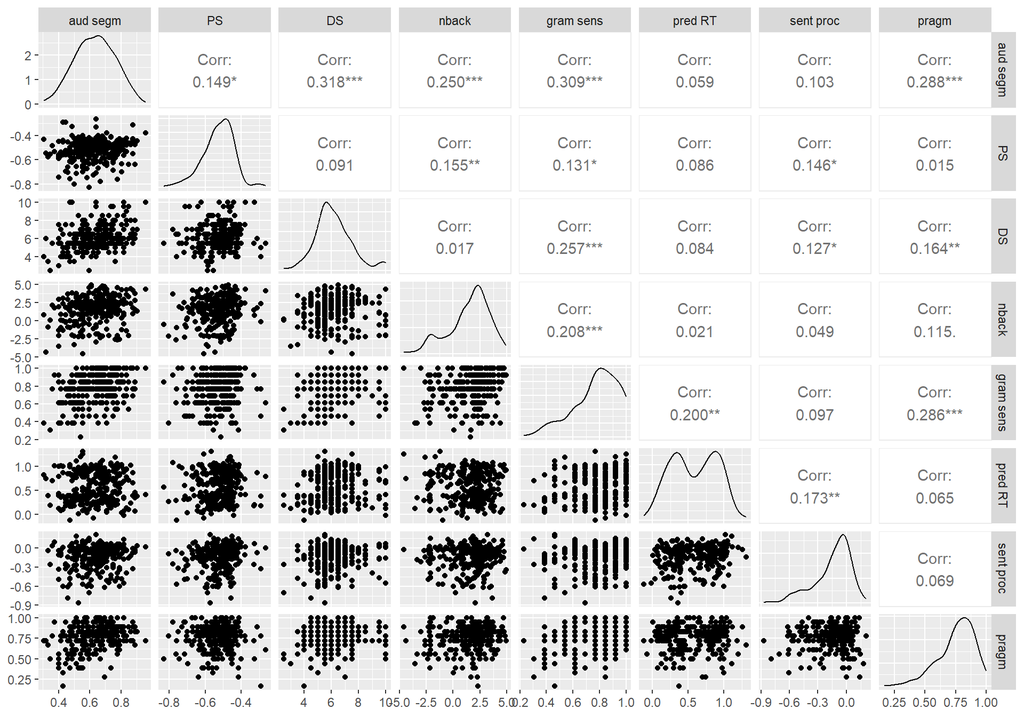

Correlations between variables in the acoustic data

## 2.2. Regression and random forest analyses

To look at specifically what predicts language abilities, we first conducted regression analyses with statistical learning, working memory, and processing speed as predictors and language abilities as outcomes.

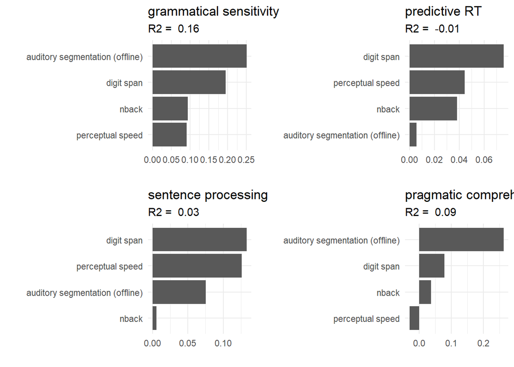

Predictor effect sizes for regression analyses with the acoustic data

In the regression analysis, only the prediction of grammatical sensitivity and pragmatic comprehension could be predicted with an interpretable fit index (R squared). In these models, auditory segmentation was an important and significant predictor.

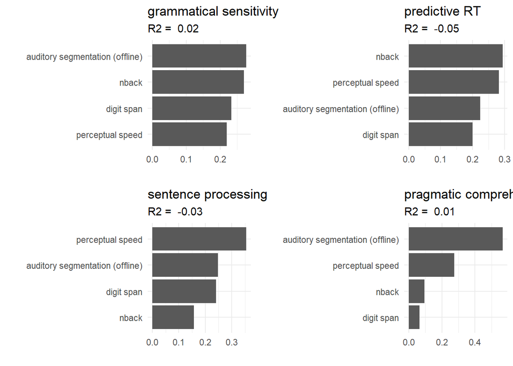

Predictor importances for random forest analyses with the acoustic data

## 2.3. Network analysis

As we were also interested in looking at the relationships between variables without the directionality to inspect how language abilities are connected to cognitive abilities. Thus, we conducted a network analysis with partial correlations (using the inverse of the correlation matrix), thus controlling for the effect of all other variables in the case of each relationship. (Only significant partial correlations are indicated on the plot.)

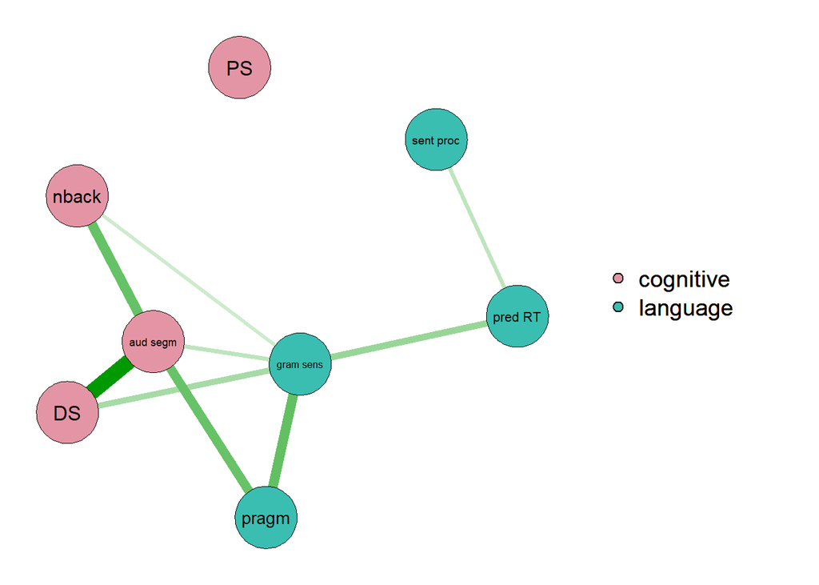

Plots of network analyses conducted on the auditory data

## 2.4. Summary

To summarize the results of the analyses, performance on the grammatical sensitivity and pragmatic comprehension tasks is the most closely correlated with cognitive ability measures. In the case of grammatical sensitivity, the auditory segmentation, digit span and nback scores were the most important cognitive variables, regression and random forest analyses indicating auditory segmentation as the most important. In the case of pragmatic comprehension, all analyses indicated auditory segmentation as the most important cognitive variable.

# 3. The effect of auditory and visual segmentation ability on language abilities

In the second part of the preliminary analyses, we looked at how auditory and visual segmentation ability explains language. Here we could only work with a smaller sample (N = 123). The methods were the same as in the case of only auditory data, except that visual statistical learning was added as an additional variable/predictor.

## 3.1. Correlations

We conducted correlations to visually inspect the relationships between variables.

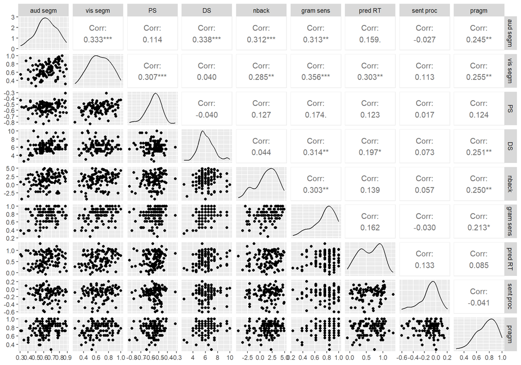

Correlations between variables in the acoustic and visual data

## 3.2. Regression and random forest analyses

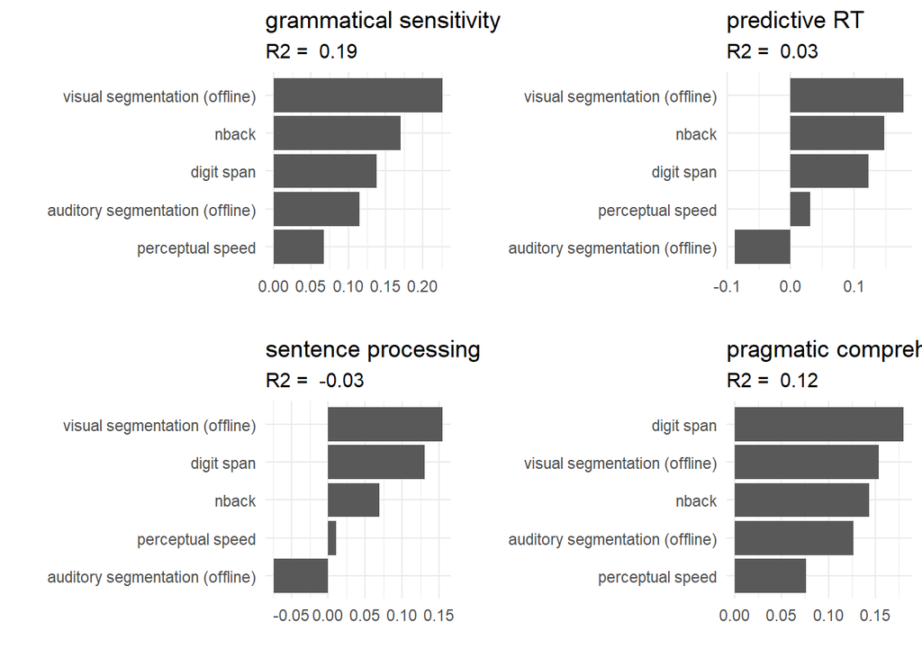

Predictor effect sizes for regression analyses with the acoustic and visual data

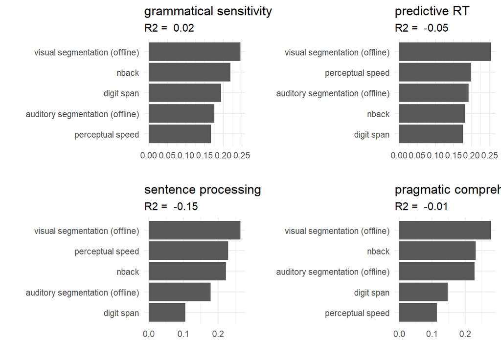

Predictor importances for random forest analyses with the acoustic and visual data

## 3.3. Network analysis

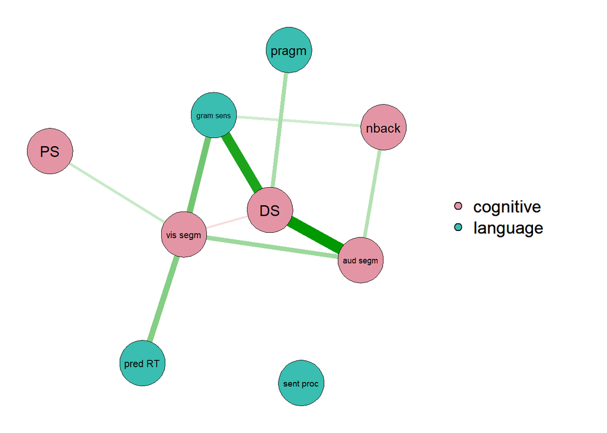

## 3.4. Summary

To summarize the results of the visual analysis, performance on the grammatical sensitivity and pragmatic comprehension tasks is the most closely correlated with cognitive ability measures, but the scores of the predictive task are also related to cognitive tasks. In the case of grammatical sensitivity, visual segmentation, nback and digit span scores were the most important cognitive variables, while auditory segmentation and processing speed were less important. In the case of predictive task scores, visual segmentation was an important predictor, but the regression and random forest analyses were both unreliable in the case of this language ability variable. In the case of pragmatic comprehension, digit span scores were important predictors, and regression and random forest analyses suggested that visual segmentation is also somewhat important (but the random forest model was not really robust).

# 4. General summary and some discussion

These preliminary analyses show that when we include auditory statistical learning, short term/working memory and perceptual speed as predictors when predicting language ability scores, auditory statistical learning ability seems to be an important predictor. However, when we include visual statistical learning, as well, this becomes more important and auditory statistical learning doesn’t explain much variation in language scores anymore. Furthermore, more “processing-based” language scores (*predictive* and *sentence processing*) were less related to cognitive abilities than more “reflection-based” language scores (*grammatical sensitivity* and *pragmatic comprehension*).

The possible explanations of the better explanatory power of visual segmentation are:

1. The visual segmetation task is more reliable and less influenced by native language representations.
2. This is only a byproduct of the modality of the tasks, because most tasks are (at least partly) administered in the visual modality

Remaining questions:

1. Why are the “reflection-based” indices more strongly correlated with cognitive factors?
2. Should we integrate NAD and AGL, and if so, how?

# 5. A first abstract version